# 「波」のつくりを探る 音の不思議？ ~Frequency analysis~

> Frequency analysis ・・・ 直訳すると、周波数解析。波という（使えない）データを、何Hzの波がどこからどこまで、どれくらいの強さ流れたのか、などといった、きちんと使える「データ」にすること。

僕は、今回の自由研究で、「音」、特に**人の声**に関して、研究をしたいと思います。

僕たちは人の声を、ああ、これは「あ」、と発音しているんだな、みたいな感じに理解できるけど、

じっさい、その音を「あ」と決めている要因はどこにあるのでしょうか・・・？

また、人の声でなくとも、「音色」というものはあります。

その「音色」を決めている要因はどこにあるのでしょうか・・・？

そういった疑問が以前からあったので、今回それを研究してみることにしました！

夏休みのちょっと前からそれを調べていて、インターネットで音について調べたり、  
大人に色々と聞いてみたりしていました。すると、音波などの「波」のつくりを探る手法（周波数解析）のひとつに、  
「フーリエ変換」というものがあって、それを使うと、波を、数字に分ける（変換する）ことができるそうです。  
波を「数字として」考えれると、研究できる要素も広がります。波の、波形だけではデータとしてはあまり使えない状態だから、  
それをきちんとした数字に変えると、その波の作りがビシっ！、とわかるようになるというわけです！

そして、その後の長い苦労（ネットサーフィン）の末・・・  
ついに、ついに「フーリエ変換」のやり方と、概要についてだいたい理解しました！  
あ、フーリエ変換のめんどくさーい計算の仕方とかはパソコンが勝手にやってくれるから、もういいや、ってしました。  
本当に道のりが長すぎて、もうこれ（ネットサーフィン）で自由研究終わりでいいよね、とか思いましたが、  
残念なことにこれをまとめなければいけません。  
本当はすぐにでも実験して、考察して、などとしたいところですが・・・・

いきなりパパッと実験して、というのは、少しフーリエ変換がフーリエ変換なだけに難しいです。  
なので、実験などをする前に、少し基礎知識が必要だと思います。  
なので、頑張って前提の知識を書いてみます。そのあとに実験タイムです。

## フーリエ変換の基礎知識。

フランスの物理学者、ジョゼフ・フーリエ男爵(1768~1830)が、フーリエ変換という理論を18世紀の終わり頃に展開した！！ その理論は、なんと音や光といった**自然界に存在する波動**を、

$ y = 10sin(2x) + 5sin(9x) + 80sin(7.9x) $

みたいな感じに、**数式**に変換することができてしまう、という代物！！！、なんです。  
数式になってしまえば、もうそれは**データの塊**みたいなものですね〜。  
だから、これがきちんとしたデータとして使える、と言ったんです！

ここに出てくる $ sin $ というのは、三角関数というものです。  
三角関数をグラフにするとこんな形になります。 これは $y = sin(x)$ のグラフです。

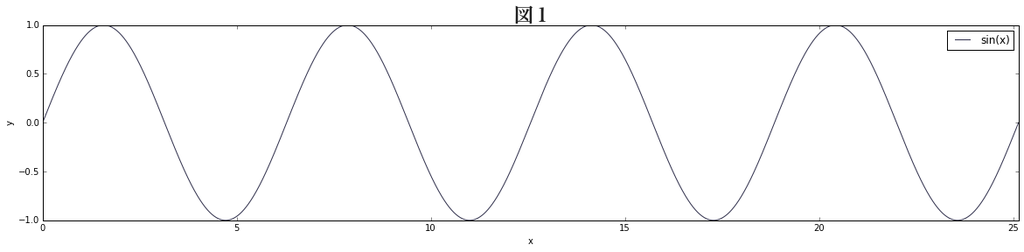

```python
%matplotlib inline

import scipy
import numpy as np
import pylab
from matplotlib.font_manager import FontProperties
fp = FontProperties(fname=r'/Library/Fonts/ヒラギノ明朝 Pro W6.otf', size=22)
fp_sml = FontProperties(fname=r'/Library/Fonts/ヒラギノ明朝 Pro W6.otf', size=16)

# 縦4、横20の大きさでグラフを描くスペースを作る
pylab.figure(figsize=(20,4))

# 0 ≦ x ≦ 10×2π(約62.83)の範囲の、10000個の点で構成された比例のグラフを作る。これがxの値になる。
x = np.linspace(0, 4*2*np.pi, 10000)

# yの値はxをsinした値で求める。
y = np.sin(x)

# 説明を添える
pylab.title('図１', fontproperties=fp, color="#202020")
pylab.xlabel('x')
pylab.ylabel('y')

# 0 ≦ x ≦ 10×2πになるようにスペースをぶった切る
pylab.xlim([0,4*2*np.pi])

#グラフを描く
pylab.plot(x, y, color="#30304c", label='sin(x)')
pylab.legend()
pylab.show()
```

これは、コンピュータの中で波形を**数学的に**作り出して、グラフにしたものです。まあ規則的だもんね、こんなの自然界にはなさそうだよね！  
灰色のボックスの中にチラチラと映る、文字記号の塊みたいなのは、コンピュータに波形を作らせる、命令文みたいなものです。プログラムってヤツです。

数学には関数という概念があって、$ sin(99) $ みたいな感じで使います。  
これは、$99$という数字を、$sin$という計算方法によって、別の数字へと変換する、という意味です。  
まあ、とにかく中でなんか計算をしているな、ということだけわかればいいです。  
それで、この $y = sin(x)$ というグラフは、その$sin$で計算するときの、元の値を$x$として、  
その$x$を$0$から$25$あたりまで、少しずつ変えていって、xの値を一律に大きくしていって、作り上げたグラフです。  
一律に大きくしていくというのは、0.001、0.002、0.003、0.004、・・・と、同じ量ずつ増やしていくイメージです。 $sin$の中に入れる数字を、そういう風に増やしながら当てはめていくと、一律に大きくしていったから一律に増えるなんてことはなくて、  
なんと曲線となってでてきちゃうのです！それが図１です。

なーんか、このグラフ、理科の授業で、音をオシロスコープで観察した実験の時の、映し出されたグラフの形に似ていませんか？

そう、そうなんです。

自然界に存在する波動というのはこの $ sin $ という数式から出てくるグラフとほぼ同じで、  
例えば、**海の波**の動きや、**地震**で生じる波、低い音から高い音までの様々な**音波**、なんとバネによって吊り下げられた**重りの振動**も、はたまた**日々の平均気温**の上下まで、**ありとあらゆる自然現象**に**「$sin$」による波形**を当てはめることができてしまうのです！

そしてこのフーリエ変換は、先ほど話した通り、そういった波動を数式、つまりデータに変換することができます。**波というのはそのままでは何もわかることがなく、このフーリエ変換を通して初めて、波からわかることが出てくるのです。**

次は、本格的にフーリエ変換、なるものが具体的にどんなものなのかを言いたいと思います。

### What is "Fourier Transform"?

フーリエ変換というのは、数学の世界でもよく使われていますが（完全な数式の中で動かす場合はフーリエ級数展開と呼ばれる）、  
工学・科学の世界でも大変重宝されています。とっても社会に役立っています。

まず、フーリエ変換と$sin$が生み出す波の、数学的な特性みたいなものを話します。

冒頭で、$ y = 10sin(2x) + 5sin(9x) + 80sin(7.9x) $という関数を見せました。（図１のグラフではないです。）

実際にフーリエ変換したときには、上の式のように数個の項で構成されているわけではなく、何千個、何万個の項で構成されています。  
数学の世界だと項が「無限」に存在することになっています。カッコイイですね。（実際に**現実世界**でフーリエ変換するとなると、さすがに「無限」はないです）  
そして、$sin$ が生み出す波にはとても興味深い特性があります。やばいです。  
先ほどの $ y = 10sin(2x) + 5sin(9x) + 80sin(7.9x) $ のような関数は、

$a \times sin(bx)$

といった項の組み合わせで表現できます。aとbにそれぞれ10だとか2だとか、数字を入れて、項が出来上がります。こう言った項が「無限」に組み合わさって、波を表現します。  
それで、例えば、ピアノで「ド」の音を鳴らすとします。しかし、それを録音したとしても、図１のような曲線にはなりません。  
図１の曲線は一番単純な波だからです。ピアノが出す音は、複雑で、**異なる**「**周波数**」の音が組み合わさって出来たものなのです。  
周波数というのは音で言えば「音の高さ」のことで、単位はHzです、というのは習いました。  
上の式では $b$ の値が、その**周波数**です。$b$ の値を大きくすればするほど、高い音になります。  
そして、$a$の値は**振幅**、音の大きさです。$a$ の値を大きくすればするほど、大きい音になります。

フーリエ変換では、波動のデータを、$a$という値と$b$という値に変換することができるできるのです！

## 早速フーリエ変換！

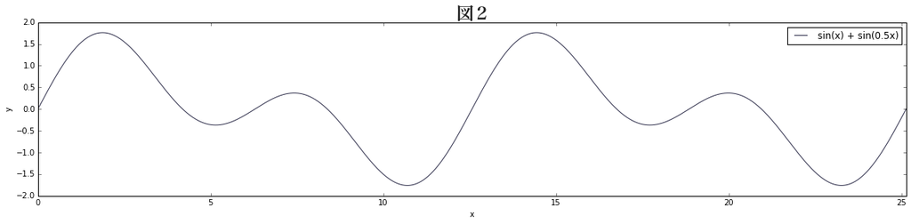

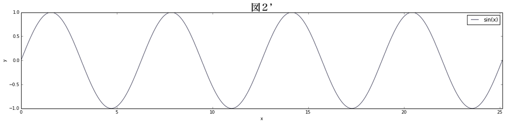

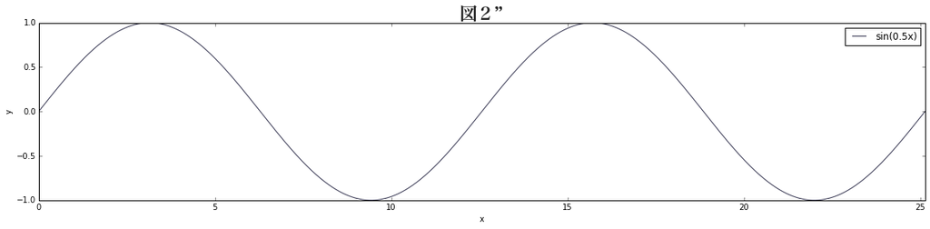

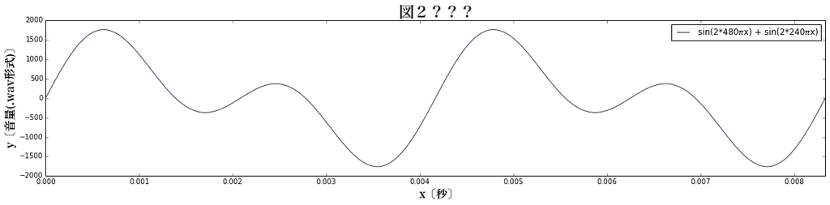

```python
import scipy.io.wavfile
pylab.figure(figsize=(20,4))

x = np.linspace(0, 400*2*np.pi, 1000000) # 比例の式
y = np.sin(x) + np.sin(0.5*x) #  y = sin(x) + sin(0.5x)
pylab.title('図２', fontproperties=fp, color="#202020") # タイトルをつけて
pylab.xlabel('x') # ラベリング
pylab.ylabel('y') # ラベリング
pylab.xlim([0,4*2*np.pi]) # 範囲を指定
pylab.plot(x, y, label="sin(x) + sin(0.5x)", color="#30304c") # 描画
pylab.legend()

pylab.show() # 描画


#========================================================================================================
#========================================================================================================
#========================================================================================================


pylab.figure(figsize=(20,4))

x = np.linspace(0, 400*2*np.pi, 1000000) # 比例の式
y = np.sin(x) #  y = sin(x)
pylab.title('図２’', fontproperties=fp, color="#202020") # タイトルをつけて
pylab.xlabel('x') # ラベリング
pylab.ylabel('y') # ラベリング
pylab.xlim([0,4*2*np.pi]) # 範囲を指定
pylab.plot(x, y, label="sin(x)", color="#30304c") # 描画
pylab.legend() # 描画




pylab.figure(figsize=(20,4))

x = np.linspace(0, 400*2*np.pi, 1000000) # 比例の式
y = np.sin(0.5*x) #  y = sin(0.5x)
pylab.title('図２”', fontproperties=fp, color="#202020") # タイトルをつけて
pylab.xlabel('x') # ラベリング
pylab.ylabel('y') # ラベリング
pylab.xlim([0,4*2*np.pi]) # 範囲を指定
pylab.plot(x, y, label="sin(0.5x)", color="#30304c") # 描画
pylab.legend() # 描画

pylab.show() # 描画


#========================================================================================================
#========================================================================================================
#========================================================================================================

sample_rate = 44100
seconds = 10

pylab.figure(figsize=(20,4))
x = np.linspace(0, seconds, sample_rate*seconds) # 比例の式、サンプルレートは44100で、10秒間だから、441000個の点で構成される。
y = 1000*(np.sin(2*np.pi*480*x) + np.sin(2*np.pi*240*x)) #  y = 1000*(sin(2*480πx) + sin(2*240πx))

pylab.title('図２？？？', fontproperties=fp, color="#202020") # タイトルをつけて
pylab.xlabel('x〔秒〕', fontproperties=fp_sml) # ラベリング
pylab.ylabel('y〔音量(.wav形式)〕', fontproperties=fp_sml) # ラベリング
pylab.xlim([0, 4/480]) # 範囲を指定
pylab.plot(x, y, label="sin(2*480πx) + sin(2*240πx)", color="#30304c") # 描画
pylab.legend() # 描画

pylab.show() # 描画


#WAVファイル書き出し。
scipy.io.wavfile.write("0001.wav", 44100, y)
```

話してばっかだと先に進みそうにないので、もう早速フーリエ変換をしてしまいます。  
まあ、理屈はいいんです。だってみなさん、でんぷんにヨウ素液を浸すと、青紫色に変色することは知っていても、  
なぜそうなるのか、とか、どうやってヨウ素液を作るのかとかは知らないでしょう。  
だから、これをこうするとこうなる！、というのがわかればいいのです！

ところで、図２を見てください！  
あれれ、これはいつものオシロスコープじゃないですね。。。 なんか山が２つある感じで、ちょっと気持ち悪い感じにカーブしてますね（筆者の感想）。  
これが、先ほど言った、複雑な波、異なる「周波数」の音が組み合わさって出来た波、なのです！  
（これでもまだ２種類の周波数を混ぜただけなので、自然界の音はもっと複雑です。）  
この波は、図２’ の波と、図２’’ の波を足し合わせて作った波です。  
つまり、図２’ の波と、図２’’ の波を同時に鳴らしたら、図２のような波になる、ということです。

実際にどんな波になるのか、聞いてみましょう！  
・・・と言いたいところですが、この波はたったの0.15Hzほどしかないので、人には聞き取れません。  
なので、図２’ の波を480Hz、図２’’ の波を240Hzということにして、240Hzの音と、480Hzの音をあわせた波として、  
作ってみました。

それが「図２？？？」です。  
え、図２と同じじゃないか、と思うかもしれません。  
でも、下の方をみてみると、単位が違います。  
「x〔秒〕」と書かれています。つまり、図２では単位がなかったのを、このグラフでは  
単位を「秒」にしちゃって、音として表現できるようにした、という感じです。

yの単位「音量(.wav形式)」とは、まあ、コンピュータ上での音声データの保存方法として「wave」という形式があるのですが、  
その「wave」の保存形式の中で用いられている、$+32767$から$-32768$までの整数で表す、**独自の**「音量」の単位です。「.wav」という拡張子のファイルでしかお目にかかれません！ 音声データをコンピュータの中に保存する時に何をやっているかというと、「図２？？？」のようなグラフを「010010・・・」みたいな  
２進数のデータにスッポリと押し込めちゃう、みたいな感じのことをやっているので、あの山の大きさ、または谷の大きさの上限を$+32767$から$-32768$までに設定して、それを元にした音量の単位です。

では、聞いてみましょう！

https://sites.google.com/site/atjiyukenkyu2015/home/0001.wav  
（ここから直接ダウンロードできます。）

[figure not shown]

（または、上記のQRコードからダウンロードできます。）

うーん、なんか・・・とても禍々しい感じの音ですね・・・  
まあ、240Hzと480Hzって、一見キリが良さそうでも、音楽的には超キリ悪いですからね・・・

では、ここから本題に移りたいと思います。  
今度は、この音を、フーリエ変換してしまいます！

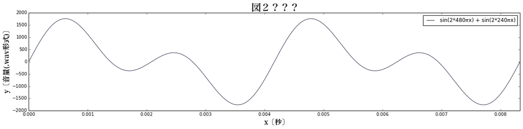

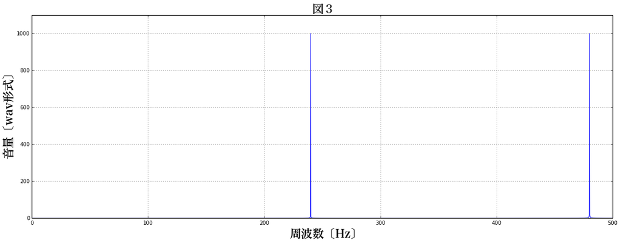

```python
"""
#フーリエ変換サンプル

signal = lambda x: 2*np.sin(x*5*2*np.pi) + np.sin(x*10*2*np.pi) + np.sin(x*15*2*np.pi)

N = 2
D = 1000

x = np.linspace(0, N, N*D)
y = signal(x)

pylab.figure(figsize=[20, 2.5])
pylab.xlim(0, 2.5)
pylab.plot(x, y)
pylab.show()

yf = scipy.fftpack.fft(y) #ここから出てくる行列の長さは、N*Dある。そのうち後半の部分はいらないので、実際の長さはN*D/2になる。
#yfをxに当てはめたときの単位を元の関数のxの単位ごとの周波数（例えば元の関数のxの単位が「秒」ならHzになる。）に揃えたいなら、
#この場合、yfの長さはN*D/2(1000)しかなく、yfが表現しうる最大の周波数（xの最大値）はD/2(500)になる。
#yをそのままプロットした時のxの最大値は1000。yを周波数に合わせてプロットした時のxの最大値は500。
#つまり、yを(D/2)/(N*D/2)倍(この場合は0.5倍)のスケールでプロットすればいい、ということになる。
xf = np.linspace(0.0, D/2, N*D/2)

pylab.xlim([0, 30])
pylab.plot(xf, 2.0/(N*D) * np.abs(yf[0:N*D/2]))
pylab.show()
"""
#あ、ちなみに↑のはコメントアウトという書き方で、プログラムを無視してるだけだから、うん、無視してね。

import scipy.fftpack

sample_rate = 44100
seconds = 10
N = 4
D = 30000

pylab.figure(figsize=(20,4))
x = np.linspace(0, N, N*D)
y = 1000*(np.sin(2*np.pi*480*x) + np.sin(2*np.pi*240*x)) #  y = 1000*(sin(2*480πx) + sin(2*240πx))

pylab.title('図２？？？', fontproperties=fp, color="#202020") # タイトルをつけて
pylab.xlabel('x〔秒〕', fontproperties=fp_sml) # ラベリング
pylab.ylabel('y〔音量(.wav形式)〕', fontproperties=fp_sml) # ラベリング
pylab.xlim([0, 4/480]) # 範囲を指定
pylab.plot(x, y, label="sin(2*480πx) + sin(2*240πx)", color="#30304c") # 描画
pylab.legend() # 描画
pylab.show() # 描画

pylab.figure(figsize=(20,7))
yf = scipy.fftpack.fft(y)
xf = np.linspace(0.0, D/2, N*D/2)
pylab.title('図３', fontproperties=fp, color="#202020") # タイトルをつけて
pylab.xlabel('周波数〔Hz〕', fontproperties=fp) # ラベリング
pylab.ylabel('音量〔wav形式〕', fontproperties=fp) # ラベリング
pylab.ylim([0, 1100])
pylab.xlim([0, 500])
pylab.grid(True)
pylab.plot(xf, 2.0/(N*D) * np.abs(yf[0:N*D/2]))
pylab.show()
```

はい、図３を見てください。ピッキリと、二筋からなる線が現れました。  
グリッド線までつけちゃいましたが、すごくわかりやすいですね（自画自賛）。グラフを見て、一発で、  
「２百うん十ヘルツの波と、4百うん十ヘルツの波が音量1000で流れたんだな」ということがわかります。  
これはx軸（横軸）がbの値、周波数で、y軸(縦軸)がaの値、音量です。  
フーリエ変換すると、複雑だったはずの波を、こんなにも簡単に「数字」として捉えることができるようになっちゃうのです！！！ （さすがに「図２？？？」のままだとよくわからん、って感じですよね。）

あっけないけど、成功です。やりました！！！フーリエ変換サマサマ、ですね！  
これで、フーリエ変換があれば、もう怖いものナッシングですよね〜！

でもあれ、違和感ないですか？  
「２百うん十ヘルツの波と、4百うん十ヘルツの波が音量1000で流れたんだな」、だけでは、まだ大事なことが残っているような気がします。  
周波数解析というのは、

> 波を何Hzの波が*どこからどこまで*、どれくらいの強さ流れたのか、などといったデータへ解析すること

でしたよね。  
これでは、「どこからどこまで」という部分がまだ解析できていないじゃないか！  
その通りです。だが心配することなかれ。大丈夫である。

フーリエ変換というのは、そういうものだからです。  
フーリエ変換というのは、とても規則的な、数学的に生み出された、それこそ、この自分のコンピュータの中で生み出した、「図１」みたいな曲線を入れないと、きれいな答えは出してくれません。というか、規則的な波形を入れないときれいな答えどころか全く使い物になりません。  
数学の世界では$sin$が作り出す波というのは永遠に同じパターンが繰り替えされますが、**現実世界**だと0.5秒間「ド」の音がなったら、今度は0.5秒間「レ」の音が鳴ったりして、永遠に同じ音、同じパターンというわけにはいきません。  
ですが、そんな**現実世界**であっても、瞬きにも満たない、ほんの「一瞬」ですが（具体的には0.01秒ほど）、  
その一瞬だけ、**同じパターンの波**が数回ほど繰り返されていたり、するのです。  
（数回ほど、というのは少ない気もします。例えば「ド」の音だと、１秒間にたったの$260回$しか、振動を許されていないという・・・。ちょっと神様はケチですよね。）  
やっぱり音を形作るのは波、それも**パターンのある波**ですので、それがなければ音程などは成り立ちません。だから、きちんとパターンはあります。  
そのパターンが維持されるのはほんの一瞬の間だけです。が、ほんの一瞬でも、積もれば山となる。それを繰り返せばいいだけの話です。  
「ほんの一瞬」だけ切り取って、フーリエ変換する。それを何百回と繰り返せば１秒になって、  
その１秒の間、音の流れがどのように変化していったのかを知ることができます。

まあ、長い間同じ音を出せば、もちろん「ほんの一瞬」とは言わず、ずっとパターンは維持されますが・・・  
この場合は「小は大を兼ねる」です。小刻みに分けて考えれば、どんな大きくて複雑なものも、飲み込める、というわけです。

### What is "Fourier Transform" used for?

では、ここですこし寄り道して、フーリエ変換が何に使われているのか、というのを話したいと思います。  
「フーリエ変換」とは、具体的になんなのか！？理論はわかったけど、感覚がわかんない！  
はい、実はここまで言っておいて、僕もあんまり理解していません！グスグス。  
「フーリエ変換」の雰囲気がわかる感じのものをちょこっとチョイスしてきたので、それで許してくださいゴメンナサイ。

まず、「フーリエ変換」はこんなところに使われています。ジャジャン！

[figure not shown]

出典：http://www.dreamstime.com/ "Sound Wave Spectrum Analyzer" © Viktor Gmyria

おお、かっこいい。ＰＶとか広告とか、テレビとかでよく見る、あのウネウネです。  
このウネウネしているのは、もろフーリエ変換のグラフです。

も、もちろんそんなことのためだけに存在してる理論ではないですよ！？  
統計学とかで、未来の景気を予測するために使われていた時期もあったし（過去形）、  
今だって、テレビや無線を使った機器（携帯、パソコンとか）などがキャッチする電磁波を、  
デジタル的なデータに変換する作業でもちろんフーリエ変換は欠かせないから、  
ほら、みんな周りのあらゆる機器にフーリエ変換の回路が埋め込まれているんです！  
そう、まさに「縁の下の力持ち」、生活を裏で支えている、すんごい理論なんですよ！  
そう、まさに「縁の下の力持ち」・・・ 活躍しているのに、ぜんぜん知られていない・・・

あとは、ちょっと面白そうな画像も見つけた！

[figure not shown]

出典：http://newt.phys.unsw.edu.au/music/clarinet/E3.html © 1997-2006 Music Acoustics UNSW

なにやら、笛の音を周波数解析しているようです。楽器の音だと結構うまくいきますね。ぴょこっと出ているところの周波数の音が、和音になって出てきているのでしょうか。いや、これは和音ではないですね。単一の音なのに、複数の突起が見える。うーん、面白いですね。

フーリエ変換ではこのような「突起」が大事で、ぴょこっとでているということはそこの周波数の音が鳴らされているという証拠です。  
そこを見ることで今何Hzの音波がでているのかを知れます。

## 実験その１。

こっからはトントン拍子にいきたいと思います。  
まず、このレポートの目標である「人の声」についての研究、ですが、  
ネタバレしちゃいますが、「人の声」でも、上にあげたような突起が見れます。  
超、ネタバレしちゃいますが、「人の声」をフーリエ変換した時の、この突起こそが、なんと「母音」と「子音」を決めているのです！  
しかし、発音する時、言いはじめの時と、言い終わりの時、また言っている途中の時とで、この突起の位置は変化してしまいます。  
今度は、一瞬だけ、一回だけ測定するというわけにはいかないのです。時間ごとに状況を把握する必要があるのです。  
では、どうするか？  
時間ごとに、視覚的に突起の位置を**観測**するには、グラフ上に「時間」を表す新たな**次元**を追加すればいいのです。  
図２は２次元のグラフです。これに「時間」という情報を追加して、３次元のグラフにしちゃえばいいんです。  
おお、3D、かっこいいじゃん！・・・と思ったあなた、残念ながら、立体でなくても、3次元のグラフにはできるので、今回は立体は使いません。  
今回は、「色」を使って、グラフを3次元のグラフにしちゃいます。  
つまり、こういう感じです。

[figure not shown]

出典：http://sethares.engr.wisc.edu/banuelos/banuelos.htm © Diego Banuelos

では、こんな感じの画像を作って、早速解析しましょう！  
今回は、STFT（短時間フーリエ変換）という手法を使って、こんな感じの、横軸が時間で、縦軸が周波数、というグラフを作ります。  
他にも、フーリエ変換を使わないでこの解析をする手段として、「ウェーブレット変換」というのがあります。そっちの方がうまく解析できるかもしれませんが、とても複雑な理論なので、今回は使いません。

http://yukara-13.hatenablog.com/entry/2013/11/17/210204 http://aidiary.hatenablog.com/entry/20110716/1310824587 このサイトを見て勉強しました。

そして、今回、解析にかける、サンプルの音は・・・  
僕の美しい鼻歌です！  
ということで、藝術的な僕の鼻歌を聞いてやってください。

https://sites.google.com/site/atjiyukenkyu2015/home/0002.wav  
（ここから直接ダウンロードできます。）

[figure not shown]

（または、上記のQRコードからダウンロードできます。）

やってきました。ついに、「最初」の実験です。  
実験の前には、予想をたてなければいけないのでしたね。

### 実験の予想

この実験では、調べた所「フォルマント」と呼ばれる、人の声を解析した時に現れる、特徴的な模様が現れるはずです。  
コンピュータの安〜いマイクから音を録ったので、ノイズなどが入ってうまくいかないかもしれませんが、まあ「フォルマント」を期待してみます。 フォルマント、というのはこんな感じのものです。

[figure not shown]

© 和歌山大学大学院システム工学研究科聴覚メディア研究室

この、もっこりしている、ミルフィーユみたいなものが出て来ればいいかな、と思っています。

### Let's 実験！

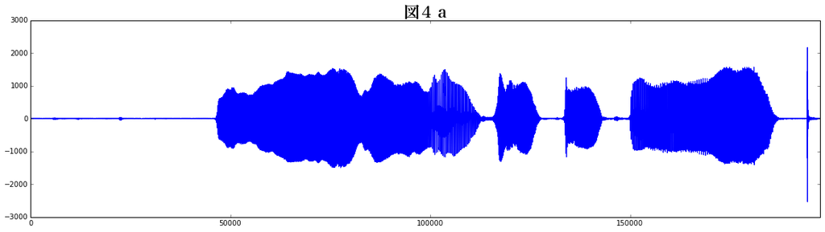

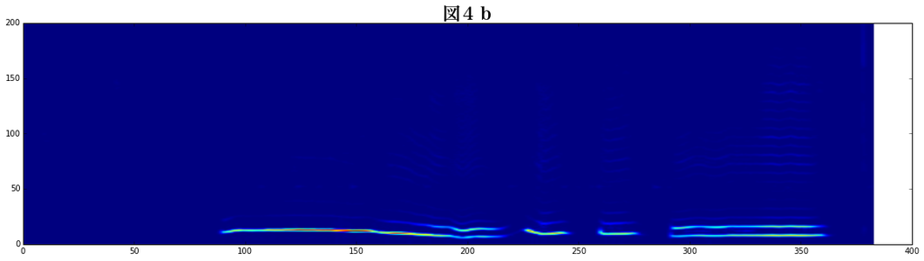

```python
# ======
#  STFT
# ======
def stft(x, win, step):
    inputlen = len(x) # 入力信号の長さ
    slicelen = len(win) # 窓幅、つまり切り出す幅
    flames = int(scipy.ceil(float(inputlen - slicelen + step) / step)) # スペクトログラムの時間フレーム数

    new_x = scipy.zeros(slicelen + ((flames - 1) * step), dtype = scipy.float64)
    new_x[:inputlen] = x # 信号をいい感じの長さにする

    X = scipy.zeros([flames, slicelen / 2], dtype = scipy.complex64) # スペクトログラムの初期化(複素数型)
    for i in range(flames):
        start = step * i
        F = scipy.fftpack.fft(new_x[start : start + slicelen] * win)
        X[i, :] = F[:len(F) / 2]

    return X

if __name__ == "__main__":
    fs, data = scipy.io.wavfile.read("0002.wav")

    fftLen = 2048 # とりあえず
    win = scipy.hamming(fftLen) # ハミング窓
    step = fftLen / 4

    ### STFT
    spectrogram = stft(data, win, step)

    ### Plot
    pylab.figure(figsize=[20,5])
    pylab.plot(data)
    pylab.xlim([0, len(data)])
    pylab.title("図４ａ", fontproperties=fp)

    pylab.figure(figsize=[20,5])
    pylab.xlim([0,400])
    pylab.ylim([0,200])
    pylab.imshow(abs(spectrogram).T, aspect = "auto", origin = "lower")
    pylab.title("図４ｂ", fontproperties=fp)
```

### 結果

なんか細長いそうめんみたいな線が数本、引かれていますね。  
正直、この結果には僕も少し驚きました。  
本当はフォルマントというものが出るはずだったのですが・・・  
今回、僕は「ん〜、ん〜、ん〜」しか言っていなかった（鼻歌だった）ので、そのフォルマントが現れなかったのかもしれません。

### 考察

ということで、実験の結果、「鼻歌にはフォルマントが現れない」ということがわかりました！  
なぜこういう結論に至ったのかというと、フォルマントは、先ほど見せたように、もっと複数の周波数が合わさってできるものです。  
このグラフはフォルマントと同じ細長い線が引かれてはいますが、フォルマントの場合はもっと線同士の密度が高いです。 これは、「鼻歌」というのは体の声を発する部分の中でも、割と単純な部分が振動しているからなのかもしれません。 あんまり厳密に実験していないから100%の説ではありませんが・・・。  
これは意外でした。ううーん、次はフォルマントをだそう！

## 実験その２

では、今度は、私が「あいうえお」と言いますので、それの解析結果を見てってください。 これも例によって、

https://sites.google.com/site/atjiyukenkyu2015/home/0003.wav  
（ここから直接ダウンロードできます。）

[figure not shown]

（または、上記のQRコードからダウンロードできます。）

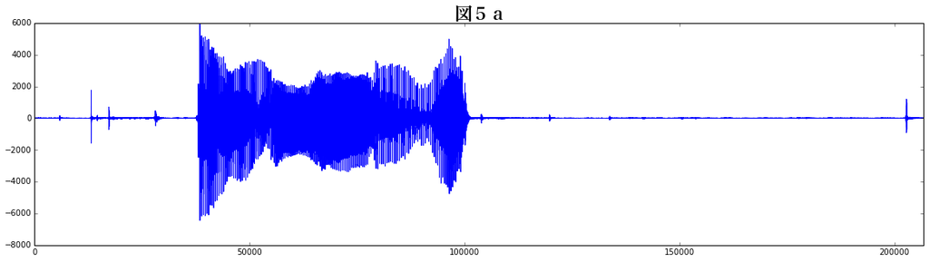

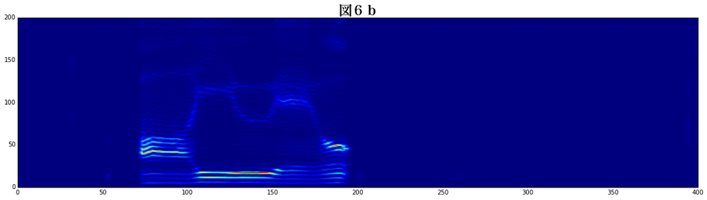

```python
if __name__ == "__main__":
    fs, data = scipy.io.wavfile.read("0003.wav")

    fftLen = 2048 # とりあえず
    win = scipy.hamming(fftLen) # ハミング窓
    step = fftLen / 4

    ### STFT
    spectrogram = stft(data, win, step)

    ### Plot
    pylab.figure(figsize=[20,5])
    pylab.plot(data)
    pylab.xlim([0, len(data)])
    pylab.title("図５ａ", fontproperties=fp)

    pylab.figure(figsize=[20,5])
    pylab.xlim([0,400])
    pylab.ylim([0,200])
    pylab.imshow(abs(spectrogram).T, aspect = "auto", origin = "lower")
    pylab.title("図６ｂ", fontproperties=fp)
```

### 結果

で、ここからの考察が面白いことになりそうです。

### 考察

「あ」の音を鳴らす時と、「お」の音を鳴らす時では、似た部位、または同じ部位を一部共有して、音を鳴らしている、と考えました。  
つまり、「あ」と「お」は音を鳴らす時に使う部位を一部共有している、という説です。  
「あ」と「お」の音は母音同士のくせにお友達、というわけです。  
これは「い」と「う」にも同じことが言えます。

まず、なぜそういう結論に至ったのかを説明します。 この仮説の実証方法はとても理科的でないので、理科的に言えば信ぴょう性はないかもしれませんが、でも信ぴょう性が「客観性」だというならば、格好自信があります。  
まず、ミルフィーユみたいなのが時折曲がったりします。これはいうまでもなく、あ、い、う、え、お、の音の変わり目です。横軸が時間軸ですので、時間軸で見ると、ミルフィーユに五種類の変化があることがわかります。これは、まあ実証するまでもなく、あ、い、う、え、お、の五種類の音をだしたから、グラフ上に五種類のフォルマントができた、ということですね。  
あ、い、う、え、お、をわかりやすく分けたものを用意しました。

[figure not shown]

で、よく見ると、「あ」のパターンと「お」がとても似通っていますよね。  
また、「い」と「う」のパターンに至っては、ほぼ同じ、と言ってもいいでしょう。

そこで僕は、音を鳴らす時に使う部位を母音同士で一部共有しているのではないか、と考えました。  
そして、問題はそれをどう実証するのかです。

僕は、実際に自分で声を上げて、その感覚で実証してみることにしました。とても原始的な方法ですね。  
まず、「あ」と「お」の音を交互にだして、感覚をつかみました。  
「あ」と「お」の音は、微妙に「お」の音の方が「あ」よりも下の方から出てきたのですが、それ以外はほぼ同じ感覚でした。非常に近い部位を共有している、という感覚です。これはグラフにも合致しています。グラフでも、「あ」と「お」は近いですが、ちょっと違っています。

次に、「い」と「う」のパターンでやってみました。  
これもグラフどおりで、完全に同じ部位を共有しているな、という感覚でした。  
念のため、「あ」と「い」、「あ」と「う」などのパターンもやってみましたが、ぜんぜん違う感覚でした。  
でも、「い」と「う」になると、「い」は鼻を鳴らしていて、「う」は鳴らしていない、という違いしかなくて、その他の箇所は全くと言っていいほど、ありません。

### 感想

そんな感じで、最後の実証の部分はとてもげんしてきな方法でしたが、これで実験２も終わりです。 当てはめてみると、本当にこのSTFTという手法は、「波」をまさに「解析」することができて、これでいろんなものが見抜けるな、と思いました。

それで、この実験２でこの自由研究も終わりにしたいかな、と思います。

皆さんも、興味を持ったなら、是非是非、「音」について研究してみてください。  
僕もまだフーリエ変換とか、周波数解析とかは**絶賛**勉強途中で、「音」や「波」についての研究はまだスタートラインにたったばかりです。 「音」について研究してみたい！という人は、いるかどうかはわかりませんが、今、僕は、僕と一緒になんかやってみたい！という人を「絶賛」募集中なので（友達少ないからね・・・）、誰でもいいのでなんかいっしょにやりませんか！？  
ここまで読んでくれた人がいるかはわかりませんが、皆様の声を、期待せず、いやちょっと期待して、待っています。

# 最後に

長いようで短い、いや実際短かった実験タイムが終了しました。ここまでお付き合いいただき本当にありがとうございまし。 この自由研究自体、自分が「フーリエ変換」に興味をもって、それの勉強と並行して作っていました。だから、ほぼ調べ学習で構成されている、とっても見苦しい、ヘンな自由研究ととなってしまいました。

ここで作ったグラフ類（自分が作ったもの）は、sciPy、numPy、というソフトウェアを使って作りました。この二つのソフトウェアは、こんな遊びみたいな自由研究ではなく、学会とかにでているガチの研究者の人もつかっている、結構すごいソフトウェアです。しかも**無料**。インストールはめんどくさいけど。

まだまだやり残したことはたくさんあるけれど、ちょっとこのままだと僕の睡眠時間がヤバいのでここらで終わりにさせていただきます。最後までありがとね！ ミ☆

# 出典・参考文献

この本の知識を全体で100%にすると、

- 僕のきっと間違っていないであろう裏付けをしていない知識 ・・・ 30%
- きっと100%確証性のあるであろう裏付けをしている知識
  - インターネットの優しい人々・・・20%
    - http://keisan.casio.jp/exec/system/1260261251 高精度計算サイト - 三角関数（度）
    - http://iphone.moo.jp/app/?p=374 MetaArt メタアートをコンセプトに送るiPhoneアプリ開発の日々 - フーリエ変換の本質
    - http://www.geocities.co.jp/AnimalPark-Shiro/1620/ft_index.html フーリエ変換基礎講座
  - 絶対に間違ったことを言わないWikipedia教授・・・50%
    - https://ja.wikipedia.org/wiki/ジョゼフ・フーリエ
    - https://ja.wikipedia.org/wiki/フーリエ変換
    - https://ja.wikipedia.org/wiki/フーリエ級数
    - https://ja.wikipedia.org/wiki/正弦波

の提供〈出典〉でお送り致しました。wikipedia便利。間違ってるとは言わせない。

あと、フーリエ変換とか、グラフの描画とかは、  
Python、というプログラミング言語を使って、コンピュータにやらせました。  
sciPy、numPyというPythonを使って数学的な計算とかができる、ソフトウェアを使いました。  
いやほんとすごいよ、この二つ。

sciPy、numPyってなに？どうやって使うの。  
あとで、学校で僕に聞いてください。

文書作成は、iPythonNotebookというツールを使いました！  
素直にWordを使えばよかったものを・・・

あと、ここまでこれたのもインターネットとGooogle先生のおかげです。感謝。